# IDG_2026 S-1

## Trabajo 1: Análisis bivariado y comparación temporal con datos censales 2017 - 2024

# "Migración y viviendas precarias: relaciones y variaciones entre 2017 y 2024 en el territorio de la Provincia de Valparaíso"

#### Profesor: Matías Escudero Bell

#### Estudiante: Gabriel González Belaúnde

..............................................................................................................................................................................................................................................................................................................

# INTRODUCCIÓN

Chile, al realizar Censos de Población y Vivienda cada cierto margen de tiempo, dispone de información estadística que describe la situación social, económica y geodemográfica de la población, con la que no solo se puede analizar el comportamiento de dichas situaciones a lo largo de un último periodo, sino que también se pueden elaborar proyecciones de dicho comportamiento a futuro. En este sentido, softwares y/o lenguajes como Jupyter, SQL o Python se convierten en útiles herramientas con las que se puede gestionar toda la gran cantidad de información que estos Censos entregan.

En este trabajo, se ha desarrollado un análisis bivariado y temporal (entre la información recabada por los Censos del 2017 y del 2024) en la Provincia de Valparaíso respecto al comportamiento y relación entre el fenómeno migratorio y la situación de viviendas precarias en la zona. De este análisis se puede interpretar entonces la relación entre estas variables a lo largo de aquellos 7 años, ahondando en aquellos sectores donde se perciben cambios más pronunciados y contrastando con la literatura reciente que traten estos temas.

El área de estudio incluye a la conurbación metropolitana denominada “Gran Valparaíso”, la que trata de la mayor urbe del país, tras su capital Santiago de Chile, y que se ha convertido un importante polo urbano de rápido crecimiento (Panez, 2015) en los últimos años. Sin embargo, durante este crecimiento urbano acelerado, se ha experimentado un deterioro de la calidad urbana; incendios en estructuras antiguas y mal mantenidas, la proliferación de terrenos tomados y la consiguiente construcción de viviendas precarias (Fuentes, 2017), la proliferación de la delincuencia e incivilidades en la vía pública (Duarte, 2022), el riesgo de que incendios forestales afecten a zonas habitadas, entre otras problemáticas, han terminado por configurar un contexto actual de crisis en la zona junto a un sentimiento de decadencia urbana y abandono político (Aravena, 2024).

Con todo, el analizar el comportamiento territorial que ha tenido la medición de la tasa de viviendas precarias durante los últimos años no solo permite observar aquellos sectores críticos donde se debiesen priorizar recursos y estrategias de desarrollo en esta problemática tan sensible en la zona, sino que además se puede comparar con otra variable como lo es el porcentaje de migrantes en estas mismas zonas censales. El fenómeno migratorio en Chile tuvo su mayor desarrollo justamente durante los años 2017 y 2024 (OCUC, 2025), por lo que comprobar el comportamiento de esta variable en conjunto al de la de tasa de viviendas precarias, representa un buen ejemplo sobre la correlación entre estas variables ya sea en el aspecto temporal como en el espacial de la zona estudiada.

# OBJETIVOS

Objetivo General:

- Analizar espacialmente la relación y comportamiento temporal entre los porcentajes de migrantes y de viviendas precarias en la Provincia de Valparaíso entre los años 2017 y 2024.

Objetivos Específicos:

- Crear un índice a partir de los datos entregados por los Censos del 2017 y 2024 sobre porcentaje de migranres y porcentaje de viviendas precarias en la Provincia de Valparaíso.
- Observar la evolución de los parámetros estudiados una desagrgación espacial a nivel de zonas censales.
- Estudiar la literatura disponible relacionada a los fenómenos analizados en la Provincia de Valparaíso.
- Realizar mapas bivariados que den cuenta de la relación espacial existente (o no) entre las variables seleccionadas.
- Constatar y caracterizar la relación entre los fenómenos demográficos y habitacional dados en la Provincia de Valparaíso en el marco de tiempo analizado, junto con interpretar las posibles causas que gatillaron dicho comportamiento.

# METODOLOGÍA

Para el presente trabajo, lo primero que se definió fue el área de estudio, que en este corresponde a la Provincia de Valparaíso. No obstante, cabe señalar que sólo se ha considerado la zona continental, descartándose así al Archipiélago de Juan Fernández y a las Islas Desventuradas. De esta forma, las comunas consideradas en este estudio son Casablanca, Valparaíso, Viña del Mar, Concón, Quintero y Puchuncaví.

Luego, para la selección de variables a estudiar, se estimó pertinente abordar la problemática de las viviendas precarias e irregulares que proliferan principalmente en las periferias de las zonas urbanas del área de estudio. Esto junto con el analizar si acaso de qué modo puede guardar relación el comportamiento del fenómeno mencionado con la evolución de la migración en la zona entre los años 2017 y 2024 (considerando a los Censos de estos años como fuente de información). Es así que se busca responder a la controversia de si acaso el fenómeno migratorio eleva o no las tasas de viviendas marginales (en este caso considerando su techumbre de materiales precarios).

En concreto, para lo anterior las variables que se buscan estudiar son:

### Porcentaje de migrantes en la zona

### Porcentaje de viviendas precarias en la zona

Dado que estos indicadores no existen como tales en la base de datos de los Censos, se procedió a crearlas a partir de los datos que sí estaban disponibles y usándolos en las siguientes ecuaciones:

## -----------------------------------------------------------------------------------------------------------

```
Porcentaje de migrantes en la zona: Toma en cuenta las respuestas de la pregunta “P12país” (para Censo 2024 es "n_inmigrantes) que es sobre el País de Nacimiento del encuestado, quedando:
```

### Porcentaje de migrantes en la Provincia de Valparaíso = (P12país/P)*100

```
Sea
P12país > 998 (es decir, extranjeros)
P = Población total por zona censal de la Provincia de Valparaíso
```

## -----------------------------------------------------------------------------------------------------------

```
Porcentaje de viviendas precarias: Toma en cuenta como viviendas precarias a aquellas que poseen techumbre (cubierta del techo) de materiales tales como planchas de zinc, planchas de fibrocemento, fonolita, paja, lata o cartón, y que se corresponden a las respuestas señaladas de la pregunta "p03país". Así:
```

### Porcentaje de viviendas precarias en la Provincia de Valparaíso = (p03b/V)*100

```
Sea
p03país ≥3 y≤6
V = Cantidad total de viviendas por zona censal de la Provincia de Valparaíso
```

## -----------------------------------------------------------------------------------------------------------

Estas variables son perfectamente calculables en base a los datos de ambos censos (INE, 2017 y 2024). Luego, el relacionarlas de forma bivariada en el territorio permitirá comprobar el tipo de conexión entre ambas variables. Cabe recalcar que toda esta información se encuentra desagregada a nivel de zona censal.

Tras estas definiciones, se procedió a recopilar los datos entregados a nivel de zona censal por el Instituto Nacional de Estadísticas, con el fin de poder comparar temporalmente las variables de interés entre los resultados del Censo 2017 y los del Censo 2024. Estos datos fueron trabajados haciendo uso de SQL y Python respectivamente, aunque también se usa el primero para manejar el gran volumen de datos del Censo 2017 en vista del tipo de archivo .backup que contenía esta información y así poder obtener los registros de cada variable deseada, mientras que el segundo sirve para no solo trabajar con el archivo .parquet (que es con el cual se tenía la información del Censo 2024), sino que además para elaborar gráficos que permitan ver el comportamiento temporal de cada fenómeno y finalmente mapear estos registros y así ver el comportamiento espacial de forma bivariada. Todo el detalle se muestra en el siguiente apartado del Desarrollo.

Además, se estudiaron distintas fuentes de literatura relacionada con la actualidad y proyección sociodemográfica y económica de la Provincia de Valparaíso, donde se reconozcan las problemáticas que se enfrentan, así como propuestas de mejora en estos ámbitos. Lo anterior es para que luego se pueda comprobar si lo arrojado por los gráficos y mapas obtenidos se condice o no con lo indicado en la literatura.

# DESARROLLO

#### 1) Carga y manejo de datos

Primero que todo, para el tratamiento de la información del Censo del 2017, se usa SQL (en 'pgAdmin'), ocupando las siguientes librerías:

```python
import os

# Fix conflicto PROJ: en equipos con PostgreSQL/PostGIS instalado, el instalador suele
# dejar PROJ_LIB (y a veces PROJ_DATA/GDAL_DATA) apuntando a su propio proj.db, que es
# mas antiguo que el que necesitan geopandas/rasterio. Se limpian ANTES de importar esas
# librerias para que cada una use su propia base de datos PROJ interna (portable entre equipos).
os.environ.pop('PROJ_LIB', None)
os.environ.pop('PROJ_DATA', None)
os.environ.pop('GDAL_DATA', None)

from sqlalchemy import create_engine
import pandas as pd
import geopandas as gpd
import matplotlib.pyplot as plt
import seaborn as sns
import mapclassify
import numpy as np
import pyreadr
import mapclassify
import contextily as cx
```

Por otro lado, se generó una Conexión a la Base de Datos local que contiene la información del Censo 2017:

```python
DB_HOST     = 'localhost'
DB_PORT     = 5432
DB_NAME     = 'censo_v_2017'
DB_USER     = 'postgres'
DB_PASSWORD = 'postgres'

engine = create_engine(
    f'postgresql+psycopg2://{DB_USER}:{DB_PASSWORD}@{DB_HOST}:{DB_PORT}/{DB_NAME}'
)
```

Una vez hecho lo anterior es que se procede a cargar los datos y con ello generar la consulta:

```python
sql_indicadores = '''
WITH agg AS
(SELECT c.nom_comuna, z.geocodigo::double precision AS geocodigo, COUNT(*) AS "total viviendas", COUNT(*) FILTER(WHERE v.p03b >= 3 and v.p03b <=6) AS "techos precarios",
ROUND(((COUNT(*) FILTER(WHERE v.p03b >= 3 and v.p03b <=6))*100.0)/COUNT(*),2) AS "porcentaje de viviendas precarias",
ROUND((COUNT(*) FILTER(WHERE p.p12pais >998)*100.0/COUNT(*)), 2) AS "porcentaje de migrantes"
FROM public.personas AS p
JOIN public.hogares AS h
ON p.hogar_ref_id = h.hogar_ref_id
JOIN public.viviendas AS v
ON h.vivienda_ref_id = v.vivienda_ref_id
JOIN public.zonas AS z
ON v.zonaloc_ref_id = z.zonaloc_ref_id
JOIN public.comunas AS c
ON z.codigo_comuna = c.codigo_comuna
JOIN public.provincias AS pr
ON pr.provincia_ref_id = c.provincia_ref_id
WHERE pr.nom_provincia = 'VALPARAÍSO' AND c.nom_comuna != 'JUAN FERNÁNDEZ'                    -- Se elimina a la comuna de Juán Fernández
GROUP BY z.geocodigo, c.nom_comuna
ORDER BY geocodigo, "porcentaje de migrantes"
)


SELECT g.*, shp.geom
FROM agg AS g
JOIN dpa.zonas_censales_v AS shp ON shp.geocodigo = g.geocodigo
WHERE g.geocodigo != '5101242001';                                                             -- Se elimina a las Islas Desventuradas
'''
```

###### La anterior consulta es la que genera un compendio de los valores de cada variable estudiada para cada zona censal correspondiente y deseada (sin la zona insular de la Provincia) y con la que finalmente a continuación se elaboran gráficos y análisis, dado que ahora poseen geometría espacial. Por otro lado, para la realización de Cartografías, es necesario que los datos con que se cuenten posean un atributo geométrico:

```python
gdf = gpd.read_postgis(sql_indicadores, engine, geom_col='geom')


sql_comunas = '''
SELECT nom_comuna, geom
FROM dpa.comunas_v
WHERE nom_provin = 'VALPARAÍSO';
'''
gdf_comunas    = gpd.read_postgis(sql_comunas, engine, geom_col='geom')
gdf_centroides = gdf_comunas.copy()
gdf_centroides['geometry'] = gdf_comunas.centroid
```

```python
# Para ver que las comunas sean efectivamente la de la Provincia:
comunas_pv = gdf['nom_comuna'].unique()
comunas_pv
```

```
<ArrowStringArray>
['VALPARAÍSO', 'CASABLANCA', 'CONCÓN', 'PUCHUNCAVÍ', 'QUINTERO',
 'VIÑA DEL MAR']
Length: 6, dtype: str
```

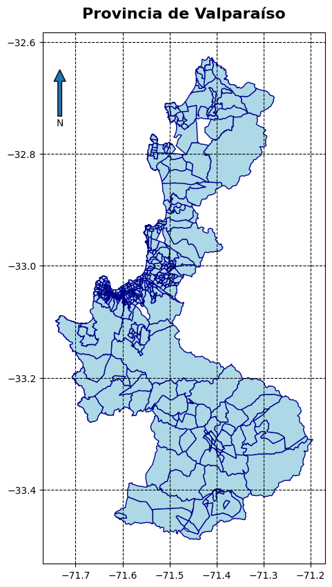

```python
fig, ax = plt.subplots(figsize=(10, 10))
gdf.plot(ax=ax, color='lightblue', edgecolor='darkblue')

ax.set_title('Provincia de Valparaíso', fontsize=16, fontweight='bold', pad=15)        # Se le añade título, grilla y flecha de Norte.
ax.grid(
    True,
    linestyle='--',
    color='black',
)

ax.annotate(
    'N',
    xy=(0.06, 0.93),
    xytext=(0.06, 0.83),
    xycoords='axes fraction',
    ha='center', va='center',
    arrowprops=dict(
        width=4,
    )
)


plt.show()
```

El mapa anterior muestra a la zona de estudio en cuestión, dividido por zonas censales. Donde se ven una concentración mayor de polígonos corresponde a aquellos sectores más densamente poblados.

Por otro lado, para el caso del Censo 2024, se trabaja netamente acá con lenguaje Python. Como se menciona en la metodología, el archivo que contiene la información de este Censo es de tipo '.parquet', por lo que se hace necesario abrir esto mediante la siguiente ruta:

```python
RUTA_CENSO24_ZONAL = "../DATA/CENSO24/Cartografía_censo2024_R05/Cartografía_censo2024_R05_Zonal.parquet"
```

```python
censo24_zonal = gpd.read_parquet(RUTA_CENSO24_ZONAL) # Esto contiene exlcusivamente a los datos de la Región de Valparaíso por zona censal.
```

```python
# Acá se realiza un filtrado de toda la información regional para solo disponer de la información provincial deseada:
pv = (censo24_zonal["PROVINCIA"] == 'VALPARAÍSO')

censo24v_zonal = censo24_zonal[pv].reset_index(drop=True)
```

Cabe señalar que para este caso del Censo 2024, no fue necesario filtrar aún más los datos como para eliminar a la zona insular, dado que en el archivo '.parquet' estas desde ya no se encontraban.

Lo que sí es necesario realizar es la construcción de las variables bajo estudio. Para ello, y en base a los datos dispuestos (y denominados en su Diccionario) del Censo 2024, las variables se presentan como:

```python
porcentaje_migrantes_2024 = (censo24v_zonal["n_inmigrantes"] / censo24v_zonal["n_per"]) * 100
porcentaje_viviendas_precarias_2024 = ((censo24v_zonal["n_mat_techo_precarios"] + censo24v_zonal["n_mat_techo_fonolita"] + censo24v_zonal["n_mat_techo_zinc"] + censo24v_zonal["n_mat_techo_fibrocemento"] + censo24v_zonal["n_mat_techo_paja"]+ censo24v_zonal["n_mat_techo_sin_cubierta"]) / censo24v_zonal["n_vp"]) * 100
```

```python
# También, bien vale saber las cantidades parciales por comuna y luego totales por variable:
censo24v_zonal['total_viviendas_precarias_temp'] = censo24v_zonal['n_mat_techo_fonolita'] + \
                                                  censo24v_zonal['n_mat_techo_precarios'] + \
                                                  censo24v_zonal['n_mat_techo_paja'] + \
                                                  censo24v_zonal['n_mat_techo_sin_cubierta'] + \
                                                  censo24v_zonal['n_mat_techo_zinc'] + \
                                                  censo24v_zonal['n_mat_techo_fibrocemento']

totales_por_comuna = censo24v_zonal.groupby('COMUNA').agg(
    n_per=('n_per', 'sum'),
    n_inmigrantes=('n_inmigrantes', 'sum'),
    n_vp=('n_vp', 'sum'),
    tot_viviendas_precarias=('total_viviendas_precarias_temp', 'sum')
).reset_index()

totales_generales = pd.DataFrame([                                    # Para ver los totales de cada variable entre todas las comunas
    {
        'COMUNA': 'TOTALES',
        'n_per': totales_por_comuna['n_per'].sum(),
        'n_inmigrantes': totales_por_comuna['n_inmigrantes'].sum(),
        'n_vp': totales_por_comuna['n_vp'].sum(),
        'tot_viviendas_precarias': totales_por_comuna['tot_viviendas_precarias'].sum()
    }
])

totales_por_comuna = pd.concat([totales_por_comuna, totales_generales], ignore_index=True)
print(totales_por_comuna)
```

```
         COMUNA     n_per  n_inmigrantes      n_vp  tot_viviendas_precarias
0    CASABLANCA   18347.0         1775.0    7092.0                   4971.0
1        CONCÓN   43048.0         3811.0   24769.0                   6052.0
2    PUCHUNCAVÍ   18620.0          811.0   17965.0                   5297.0
3      QUINTERO   28348.0         1158.0   15755.0                   7853.0
4    VALPARAÍSO  277116.0        12618.0  127250.0                  69499.0
5  VIÑA DEL MAR  330109.0        21230.0  161807.0                  69323.0
6       TOTALES  715588.0        41403.0  354638.0                 162995.0
```

#### 2) EDA

A continuación, y una vez asegurada la obtención y filtración de los datos requeridos, se realiza un Análisis Exploratorio de Datos (EDA) con el fin de observar preliminarmente el comportamiento de cada variable por sí sola en el territorio. Luego, en el apartado de Análisis y Discusión se interpretará lo obtenido.

### - Distribución de las variables estudiadas: comportamiento univariado

Las siguientes figuras corresponden a gráficas del comportamiento de cada variable en cada CENSO estudiado por separado:

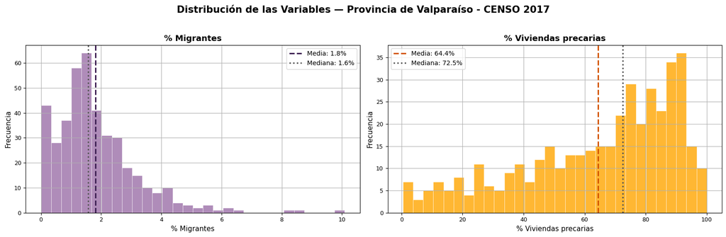

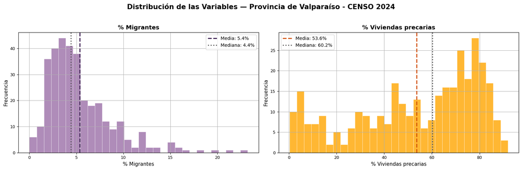

```python
# CENSO 2017
fig, axes = plt.subplots(1, 2, figsize=(16, 5))
fig.patch.set_facecolor('white')
fig.suptitle('Distribución de las Variables — Provincia de Valparaíso - CENSO 2017',
             fontsize=15, fontweight='bold', y=1.03)
vars_config = [
    ('porcentaje de migrantes',    '#9b6fa8', '#3d1f52', '% Migrantes'),
    ('porcentaje de viviendas precarias', '#FFA500', '#D35400', '% Viviendas precarias'),
]

for ax, (col, color, color_dark, label) in zip(axes, vars_config):
    datos = gdf[col].dropna()
    ax.hist(datos, bins=30, color=color, edgecolor='white', linewidth=0.5, alpha=0.8)
    ax.axvline(datos.mean(),   color=color_dark, ls='--', lw=2.2,
               label=f'Media: {datos.mean():.1f}%')
    ax.axvline(datos.median(), color='#555',     ls=':',  lw=2.2,
               label=f'Mediana: {datos.median():.1f}%')
    ax.set_title(label, fontweight='bold', fontsize=13)
    ax.set_xlabel(label, fontsize=11)
    ax.set_ylabel('Frecuencia', fontsize=11)
    ax.legend(fontsize=10)
    ax.tick_params(labelsize=9)
    ax.grid(True)

plt.tight_layout()
plt.show()


# CENSO 2024
fig, axes = plt.subplots(1, 2, figsize=(16, 5))
fig.patch.set_facecolor('white')
fig.suptitle('Distribución de las Variables — Provincia de Valparaíso - CENSO 2024',
             fontsize=15, fontweight='bold', y=1.03)
vars_config = [
    (porcentaje_migrantes_2024,    '#9b6fa8', '#3d1f52', '% Migrantes'),
    (porcentaje_viviendas_precarias_2024, '#FFA500', '#D35400', '% Viviendas precarias'),
]

for ax, (data_series, color, color_dark, label) in zip(axes, vars_config):
    datos = data_series.dropna()
    ax.hist(datos, bins=30, color=color, edgecolor='white', linewidth=0.5, alpha=0.8)
    ax.axvline(datos.mean(),   color=color_dark, ls='--', lw=2.2,
               label=f'Media: {datos.mean():.1f}%')
    ax.axvline(datos.median(), color='#555',     ls=':',  lw=2.2,
               label=f'Mediana: {datos.median():.1f}%')
    ax.set_title(label, fontweight='bold', fontsize=13)
    ax.set_xlabel(label, fontsize=11)
    ax.set_ylabel('Frecuencia', fontsize=11)
    ax.legend(fontsize=10)
    ax.tick_params(labelsize=9)
    ax.grid(True)


plt.tight_layout()
plt.show()
```

Ahora, las siguientes figuras muestran el comportamiento estadístico por comuna de cada variable en cada CENSO estudiado:

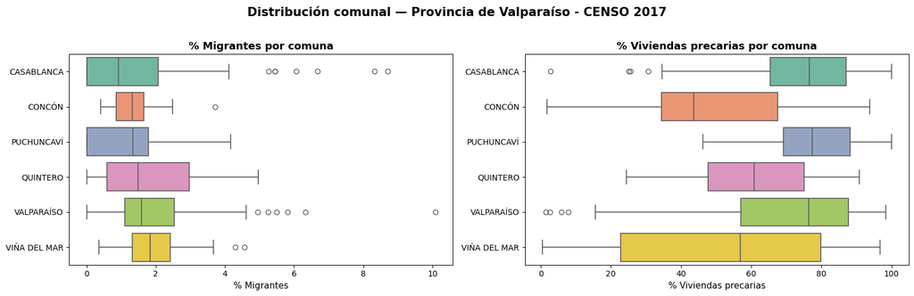

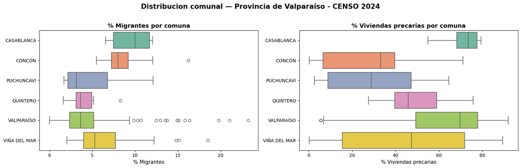

```python
# CENSO 2017
fig, axes = plt.subplots(1, 2, figsize=(16, 5))
fig.patch.set_facecolor('white')
fig.suptitle('Distribución comunal — Provincia de Valparaíso - CENSO 2017',
             fontsize=15, fontweight='bold', y=1.02)

n_comunas = gdf['nom_comuna'].nunique()
pal = sns.color_palette('Set2', n_colors=n_comunas)
orden = sorted(gdf['nom_comuna'].unique())  # Orden alfabético de comunas

config = [
    (axes[0], 'porcentaje de migrantes', '% Migrantes'),
    (axes[1], 'porcentaje de viviendas precarias', '% Viviendas precarias'),
]

for ax, col, label in config:
    sns.boxplot(
        data=gdf, y='nom_comuna', x=col, order=orden,
        palette=pal, ax=ax, linewidth=1.2
    )
    ax.set_title(f'{label} por comuna', fontweight='bold', fontsize=13)
    ax.set_xlabel(label, fontsize=11)
    ax.set_ylabel('')

plt.tight_layout()
plt.show()


# CENSO 2024
fig, axes = plt.subplots(1, 2, figsize=(16, 5))
fig.patch.set_facecolor('white')
fig.suptitle('Distribucion comunal — Provincia de Valparaíso - CENSO 2024',
             fontsize=15, fontweight='bold', y=1.02)

n_comunas = censo24v_zonal['COMUNA'].nunique()
pal = sns.color_palette('Set2', n_colors=n_comunas)

vars_config_for_plot = [
    (porcentaje_migrantes_2024,    '% Migrantes'),
    (porcentaje_viviendas_precarias_2024, '% Viviendas precarias'),
]

for i, (data_series, label) in enumerate(vars_config_for_plot):
    ax = axes[i]
    temp_df_for_plot = pd.DataFrame({
        'COMUNA': censo24v_zonal['COMUNA'],
        'value': data_series
    })

    orden =     orden = sorted(temp_df_for_plot['COMUNA'].unique())     # Orden alfabético para las comunas
    sns.boxplot(
        data = temp_df_for_plot, y='COMUNA', x='value', order=orden,
        palette=pal,
        ax=ax, linewidth=1.2
    )
    ax.set_title(f'{label} por comuna', fontweight='bold', fontsize=13)
    ax.set_xlabel(label, fontsize=11)
    ax.set_ylabel('')

plt.tight_layout()
plt.show()
```

Finalmente, a contiuación se muestran los comportamientos en el territorio de cada variable en cada CENSO estudiado:

[figure not shown]

```python
gdf_continental = gdf[gdf.geometry.centroid.x > -72]
# Reproyectar a Web Mercator
gdf_3857 = gdf_continental.to_crs(epsg=3857)
gdf_comunas_3857 = gdf_comunas.to_crs(epsg=3857)

# --- Generación de Mapas con Zoom Específico ---
fig, ax = plt.subplots(1, 2, figsize=(20, 10))

# Ajustamos los límites manualmente para enfocarnos en el área metropolitana
# Estos valores en EPSG:3857 corresponden aproximadamente al área urbana continental
xmin, ymin, xmax, ymax = -8000000, -3970000, -7915000, -3840000          # O, S, E, N

# Comportamiento espacial univariado migrantes CENSO 2017 (izquierda)
gdf_3857.plot(column='porcentaje de migrantes', ax=ax[0], legend=True,
              cmap='Purples',
              scheme='FisherJenks',
              k=5,
              edgecolor='black',
              linewidth=0.5,
              alpha=0.7,
              legend_kwds={'title': "Porcentaje (%)", 'loc': 'lower right'})
gdf_comunas_3857.plot(ax=ax[0], color='none', edgecolor='black', linewidth=2)
cx.add_basemap(ax[0], source=cx.providers.OpenStreetMap.Mapnik)
ax[0].set_xlim(xmin, xmax)
ax[0].set_ylim(ymin, ymax)
ax[0].set_title('% Población Migrante por zona censal - CENSO 2017', fontsize=14)
ax[0].axis('off')

# Comportamiento espacial univariado viviendas CENSO 2017 (derecha)
gdf_3857.plot(column='porcentaje de viviendas precarias', ax=ax[1], legend=True,
              cmap='OrRd', scheme='FisherJenks', k=5, alpha=0.7,
              edgecolor='black',
              linewidth=0.5,
              legend_kwds={'title': "Porcentaje (%)", 'loc': 'lower right'})
gdf_comunas_3857.plot(ax=ax[1], color='none', edgecolor='black', linewidth=2)
cx.add_basemap(ax[1], source=cx.providers.OpenStreetMap.Mapnik)
ax[1].set_xlim(xmin, xmax)
ax[1].set_ylim(ymin, ymax)
ax[1].set_title('% Viviendas Precarias por zona censal - CENSO 2017', fontsize=14)
ax[1].axis('off')

plt.tight_layout()
plt.show()
```

[figure not shown]

```python
# Comportamiento territorial univariado CENSO 2024
def plot_univariado(ax, censo24v_zonal_z, censo24v_zonal_c, censo24v_zonal_ct, col, cmap, titulo, cbar_label):
    censo24v_zonal_z.plot(
        column=col, ax=ax, cmap=cmap, linewidth=0,
        legend=True,
        legend_kwds={'label': cbar_label, 'shrink': 0.55, 'pad': 0.02}
    )
    censo24v_zonal_c.plot(ax=ax, facecolor='none', edgecolor='#111', linewidth=1.8)
    for _, row in censo24v_zonal_ct.iterrows():
        ax.annotate(
            row.name,
            xy=(row.geometry.x, row.geometry.y),
            ha='center', va='center',
            fontsize=9, fontweight='bold', color='#111',
            bbox=dict(boxstyle='round,pad=0.2', fc='white', alpha=0.65, ec='none')
        )
    ax.set_title(titulo, fontsize=12, fontweight='bold', pad=10)
    ax.grid(True, linestyle='--', alpha=0.6)
    x, y, arrow_length = 0.1, 0.75, 0.18
    ax.annotate('N',
                xy=(x, y),
                xytext=(x, y - arrow_length),
                arrowprops=dict(facecolor='black', width=1, headwidth=6, headlength=10),
                ha='center', va='center',
                fontsize= 20, fontweight='bold', color='black',
                xycoords='axes fraction', textcoords='axes fraction')
    ax.set_xlabel('Longitud', fontsize=10)
    ax.set_ylabel('Latitud', fontsize=10)
    ax.tick_params(axis='x', rotation=45, labelsize=8)
    ax.tick_params(axis='y', labelsize=8)

    cx.add_basemap(ax, crs=censo24v_zonal_z.crs.to_string(), source=cx.providers.CartoDB.Positron)     # Acá se añade un mapa base

if 'SHAPE' in censo24v_zonal.columns:
    censo24v_zonal = censo24v_zonal.set_geometry('SHAPE').rename_geometry('geometry')
if censo24v_zonal.crs is None:
    censo24v_zonal.set_crs(epsg=4326, inplace=True)
else:
    censo24v_zonal = censo24v_zonal.to_crs(epsg=4326)
censo24v_zonal['porcentaje_migrantes_2024'] = porcentaje_migrantes_2024
censo24v_zonal['porcentaje_viviendas_precarias_2024'] = porcentaje_viviendas_precarias_2024
censo24v_zonal_comunas = censo24v_zonal.dissolve(by='COMUNA')
censo24v_zonal_centroides = censo24v_zonal_comunas.copy()
censo24v_zonal_centroides.geometry = censo24v_zonal_comunas.geometry.centroid.to_crs(epsg=4326)


fig, axes = plt.subplots(1, 2, figsize=(15, 12))
fig.patch.set_facecolor('#fafafa')
plot_univariado(
    axes[0], censo24v_zonal, censo24v_zonal_comunas, censo24v_zonal_centroides,
    'porcentaje_migrantes_2024', 'Purples',
    '% Migrantes por zona censal — Provincia de Valparaíso - CENSO 2024',
    '% Migrantes'
)
plot_univariado(
    axes[1], censo24v_zonal, censo24v_zonal_comunas, censo24v_zonal_centroides,
    'porcentaje_viviendas_precarias_2024', 'Oranges',
    '% Viviendas precarias por zona censal — Provincia de Valparaíso - CENSO 2024',
    '% Viviendas precarias'
)

plt.tight_layout(pad=2)
plt.show()
```

#### 3) Comparativa en bivariado

Ahora, corresponde a mostrar cómo es que se comportan las variables de interés de forma comparadas entre sí y aplicadas en el territorio:

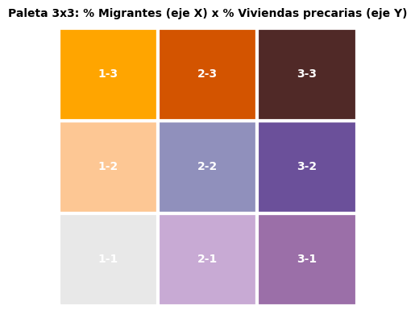

```python
# Paleta para comparación bivariada para ambos CENSOS:
BIVARIATE_COLORS = {
    '1-1': '#e8e8e8',
    '2-1': '#c8aad4',
    '3-1': '#9b6fa8',
    '1-2': '#FDC794',
    '2-2': '#9090bc',
    '3-2': '#6b509a',
    '1-3': '#FFA500',
    '2-3': '#D35400',
    '3-3': '#502927',
}

fig_pal, ax_pal = plt.subplots(figsize=(4, 4))
for key, color in BIVARIATE_COLORS.items():
    i, j = map(int, key.split('-'))
    ax_pal.add_patch(plt.Rectangle(
        ((i - 1) / 3, (j - 1) / 3), 1/3, 1/3,
        transform=ax_pal.transAxes,
        facecolor=color, edgecolor='white', linewidth=3, clip_on=False
    ))
    ax_pal.text(
        (i - 0.5) / 3, (j - 0.5) / 3, key,
        ha='center', va='center', fontsize=10, color='white',
        fontweight='bold', transform=ax_pal.transAxes
    )
ax_pal.set_xlim(0, 1)
ax_pal.set_ylim(0, 1)
ax_pal.axis('off')
ax_pal.set_title('Paleta 3x3: % Migrantes (eje X) x % Viviendas precarias (eje Y)',
                 fontsize=10, fontweight='bold', pad=10)
plt.tight_layout()
plt.show()
```

[figure not shown]

```python
gdf = gpd.read_postgis(sql_indicadores, engine, geom_col='geom')
gdf = gdf.to_crs(epsg=3857)

sql_comunas = '''
SELECT nom_comuna, geom
FROM dpa.comunas_v
WHERE nom_provin = 'VALPARAÍSO' AND nom_comuna != 'JUAN FERNÁNDEZ';
'''
gdf_comunas = gpd.read_postgis(sql_comunas, engine, geom_col='geom')
gdf_comunas = gdf_comunas.to_crs(epsg=3857)

gdf_centroides = gdf_comunas.copy()
gdf_centroides['geometry'] = gdf_comunas.centroid

# --- Procesamiento Bivariado ---
cls_x = mapclassify.FisherJenks(gdf['porcentaje de migrantes'].values, k=3)
cls_y = mapclassify.FisherJenks(gdf['porcentaje de viviendas precarias'].values, k=3)

gdf['class_x'] = cls_x.yb + 1
gdf['class_y'] = cls_y.yb + 1
gdf['bi_class'] = gdf['class_x'].astype(str) + '-' + gdf['class_y'].astype(str)
gdf['color'] = gdf['bi_class'].map(BIVARIATE_COLORS)

def crear_leyenda_bivariada(ax, colores, xlab, ylab, dim=3):
    for i in range(1, dim + 1):
        for j in range(1, dim + 1):
            ax.add_patch(plt.Rectangle(
                ((i - 1) / dim, (j - 1) / dim),
                1 / dim, 1 / dim,
                transform=ax.transAxes,
                facecolor=colores[f'{i}-{j}'],
                edgecolor='white', linewidth=1.5, clip_on=False
            ))
    ax.set_xticks([]); ax.set_yticks([])
    ax.text(0.5, -0.15, xlab, ha='center', fontsize=8, transform=ax.transAxes, fontweight='bold')
    ax.text(-0.15, 0.5, ylab, va='center', rotation=90, fontsize=8, transform=ax.transAxes, fontweight='bold')

# --- Visualización ---
fig = plt.figure(figsize=(16, 12))
fig.patch.set_facecolor('#f5f0e8')

ax_map = fig.add_axes([0.02, 0.05, 0.70, 0.82])
ax_leg = fig.add_axes([0.75, 0.20, 0.15, 0.15])


# --- ZOOM ESPECÍFICO: ÁREA METROPOLITANA DE VALPARAÍSO ---
x_min, x_max = -8000000, -7915000
y_min, y_max = -3970000, -3840000

ax_map.set_xlim(x_min, x_max)
ax_map.set_ylim(y_min, y_max)

# Dibujar capas con transparencia (alpha) para ver el mapa base
gdf.plot(color=gdf['color'].tolist(), ax=ax_map, linewidth=0.1, edgecolor='#aaaaaa', zorder=2, alpha=0.7)
gdf_comunas.plot(ax=ax_map, facecolor='none', edgecolor='#111111', linewidth=2.0, zorder=4)

# --- AÑADIR MAPA BASE ---
cx.add_basemap(ax_map, source=cx.providers.CartoDB.Positron, zorder=1)

# Etiquetas:
for _, row in gdf_centroides.iterrows():
    if x_min < row.geometry.x < x_max and y_min < row.geometry.y < y_max:
        txt = ax_map.annotate(row['nom_comuna'], xy=(row.geometry.x, row.geometry.y),
                              ha='center', va='center', fontsize=10, fontweight='bold', zorder=6)
        txt.set_path_effects([pe.withStroke(linewidth=3, foreground='white')])

ax_map.set_xticks([]); ax_map.set_yticks([])

fig.text(0.37, 0.95, '% Migrantes  V/S  % Viviendas precarias - CENSO 2017', ha='center', fontsize=20, fontweight='bold')
fig.text(0.37, 0.938, 'MAPA BIVARIADO', ha='center',
         fontsize=12, color='#444', style='italic')
fig.text(0.37, 0.914, 'Provincia de Valparaíso  .  Zonas Censales  .  Censo 2017',
         ha='center', fontsize=9.5, color='#777')
crear_leyenda_bivariada(ax_leg, BIVARIATE_COLORS, '% Migrantes →', '% Precarias →')
ax_leg.set_title('Paleta Bivariada', fontsize=28.5, fontweight='bold', pad=7, color='#333')

plt.show()
```

```
Cortes Jenks — % Migrantes:
[np.float64(23.22), np.float64(23.22), np.float64(nan)]

Cortes Jenks — % Viviendas precarias >= 16:
[np.float64(26.55), np.float64(59.24), np.float64(91.88)]

Distribucion de clases bivariadas:
bi_class
1-1     62
1-2    105
1-3    169
Name: count, dtype: int64

Todas las zonas tienen color asignado
```

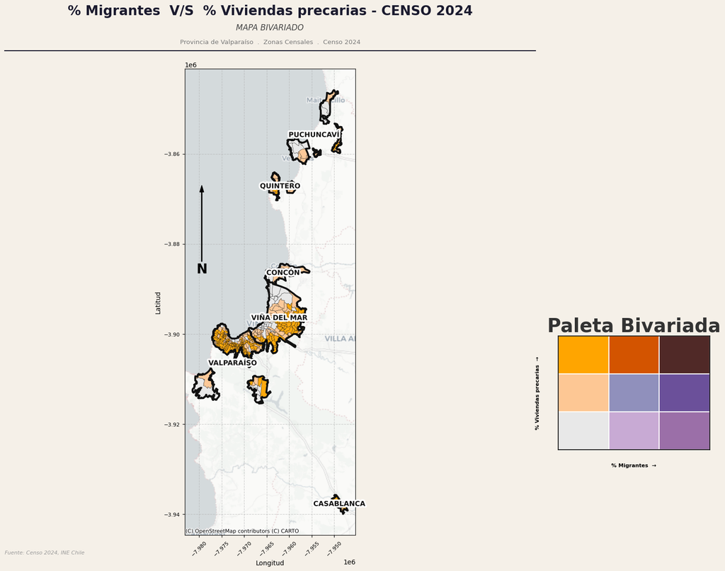

```python
# CENSO 2024 bivariado:
import matplotlib.patheffects as pe
from matplotlib.lines import Line2D
import contextily as cx

censo24v_zonal['porcentaje_migrantes_2024'] = porcentaje_migrantes_2024
censo24v_zonal['porcentaje_viviendas_precarias_2024'] = porcentaje_viviendas_precarias_2024

cls_x = mapclassify.FisherJenks(censo24v_zonal['porcentaje_migrantes_2024'].values,    k=3)
cls_y = mapclassify.FisherJenks(censo24v_zonal['porcentaje_viviendas_precarias_2024'].values, k=3)

gdf_biv = censo24v_zonal.copy()
gdf_biv['class_x']  = cls_x.yb + 1
gdf_biv['class_y']  = cls_y.yb + 1
gdf_biv['bi_class'] = gdf_biv['class_x'].astype(str) + '-' + gdf_biv['class_y'].astype(str)
gdf_biv['color']    = gdf_biv['bi_class'].map(BIVARIATE_COLORS)

print('Cortes Jenks — % Migrantes:')
print([round(b, 2) for b in cls_x.bins])
print('\nCortes Jenks — % Viviendas precarias >= 16:')
print([round(b, 2) for b in cls_y.bins])
print(f'\nDistribucion de clases bivariadas:')
print(gdf_biv['bi_class'].value_counts().sort_index())

sin_color = gdf_biv[gdf_biv['color'].isna()]
if len(sin_color) == 0:
    print('\nTodas las zonas tienen color asignado')
else:
    print(f'\nAtencion: {len(sin_color)} zonas sin color: {sin_color["bi_class"].unique()}')


# ── Figura y layout ───────────────────────────────────────────────────────────
fig = plt.figure(figsize=(16, 12))
fig.patch.set_facecolor('#f5f0e8')      # fondo

ax_map = fig.add_axes([0.02, 0.05, 0.70, 0.82])
ax_leg = fig.add_axes([0.75, 0.20, 0.20, 0.20])

# ── Mapa ─────────────────────────────────────────────────────────────────────
ax_map.set_facecolor('#b8d4e8')         # azul suave

if not isinstance(censo24v_zonal, gpd.GeoDataFrame):
    censo24v_zonal = gpd.GeoDataFrame(censo24v_zonal, geometry=gpd.GeoSeries.from_wkb(censo24v_zonal['SHAPE']), crs='epsg:4326')
if 'porcentaje_migrantes_2024' not in censo24v_zonal.columns:
    censo24v_zonal['porcentaje_migrantes_2024'] = porcentaje_migrantes_2024
if 'porcentaje_viviendas_precarias_2024' not in censo24v_zonal.columns:
    censo24v_zonal['porcentaje_viviendas_precarias_2024'] = porcentaje_viviendas_precarias_2024

# Crear gdf_bi y reproyectarlo
gdf_bi_initial = censo24v_zonal.copy()
gdf_bi_initial['class_x']  = cls_x.yb + 1
gdf_bi_initial['class_y']  = cls_y.yb + 1
gdf_bi_initial['bi_class'] = gdf_bi_initial['class_x'].astype(str) + '-' + gdf_bi_initial['class_y'].astype(str)
gdf_bi_initial['color']    = gdf_bi_initial['bi_class'].map(BIVARIATE_COLORS)

gdf_bi_proj = gdf_bi_initial.to_crs(epsg=3857)

# Definir gdf_comunas y gdf_centroides a partir de gdf_bi_proj
gdf_comunas_proj = gdf_bi_proj.dissolve(by='COMUNA')
gdf_centroides_proj = gdf_comunas_proj.copy()
gdf_centroides_proj.geometry = gdf_comunas_proj.geometry.centroid

# Zonas censales
gdf_bi_proj.plot(
    color=gdf_bi_proj['color'].tolist(), ax=ax_map,
    zorder=2, alpha=0.95
)
gdf_bi_proj.boundary.plot(
    ax=ax_map,
    color='#000000',
    linewidth=0.2,
    zorder=2,
)

# Mapa base (contextily)
cx.add_basemap(ax_map, crs=gdf_bi_proj.crs.to_string(), source=cx.providers.CartoDB.Positron)

# Limites comunales:
gdf_comunas_proj.plot(
    ax=ax_map, facecolor='none', edgecolor='#111111',
    linewidth=2.8, zorder=4
)

# Etiquetas:
for _, row in gdf_centroides_proj.iterrows():
    txt = ax_map.annotate(
        row.name,
        xy=(row.geometry.x, row.geometry.y),
        ha='center', va='center',
        fontsize=10.5, fontweight='bold', color='#111111', zorder=6
    )
    txt.set_path_effects([pe.withStroke(linewidth=5, foreground='white')])

# Grilla y Norte:
ax_map.grid(True, linestyle='--', alpha=0.6)
x, y, arrow_length = 0.1, 0.75, 0.18 # Posición y tamaño de la flecha en coordenadas del eje
ax_map.annotate('N',
                xy=(x, y),
                xytext=(x, y - arrow_length),
                arrowprops=dict(facecolor='black', width=1, headwidth=6, headlength=10),
                ha='center', va='center',
                fontsize= 20, fontweight='bold', color='black',
                xycoords='axes fraction', textcoords='axes fraction')

# Mostrar etiquetas de latitud y longitud
ax_map.set_xlabel('Longitud', fontsize=10)
ax_map.set_ylabel('Latitud', fontsize=10)
ax_map.tick_params(axis='x', rotation=45, labelsize=8)
ax_map.tick_params(axis='y', labelsize=8)

# Marco del mapa:
for spine in ax_map.spines.values():
    spine.set_visible(True)
    spine.set_color('#000000')
    spine.set_linewidth(0.8)

# Textos:
fig.text(0.37, 0.965, '% Migrantes  V/S  % Viviendas precarias - CENSO 2024', ha='center',
         fontsize=20, fontweight='bold', color='#1a1a2e')
fig.text(0.37, 0.938, 'MAPA BIVARIADO', ha='center',
         fontsize=12, color='#444', style='italic')
fig.text(0.37, 0.914, 'Provincia de Valparaíso  .  Zonas Censales  .  Censo 2024',
         ha='center', fontsize=9.5, color='#777')
fig.add_artist(Line2D([0.02, 0.72], [0.902, 0.902],
                      transform=fig.transFigure,
                      color='#1a1a2e', linewidth=1.5))
fig.text(0.02, 0.017, 'Fuente: Censo 2024, INE Chile',
         ha='left', fontsize=8, color='#999', style='italic')

# ── Leyenda bivariada ───
# Estilo del axes de leyenda: fondo blanco con borde gris
ax_leg.set_facecolor('000000')
for spine in ax_leg.spines.values():
    spine.set_visible(True)
    spine.set_color('#000000')
    spine.set_linewidth(1.2)

crear_leyenda_bivariada(
    ax_leg, BIVARIATE_COLORS,
    xlab='% Migrantes  →',
    ylab='% Viviendas precarias  →'
)
ax_leg.set_title('Paleta Bivariada', fontsize=28.5, fontweight='bold', pad=7, color='#333')

plt.show()
```

### 4) Comparación bivariada

```python
# A continuación, y mediante gracias a un código sugerido por IA, se muestra un GIF de una Comparativa Bivariada Temporal:
!pip install imageio
import imageio
from PIL import Image

def generar_mapa_bivariado_frame(gdf_plot, gdf_comunas_plot, titulo_year, output_filename):
    """Genera y guarda un frame del mapa con una extensión fija."""
    fig = plt.figure(figsize=(16, 12))
    fig.patch.set_facecolor('#f5f0e8')

    ax_map = fig.add_axes([0.02, 0.05, 0.70, 0.82])
    ax_leg = fig.add_axes([0.75, 0.20, 0.15, 0.15])

    # Fijamos el zoom para que el GIF no salte (Área Metropolitana de Valparaíso)
    x_min, x_max = -8000000, -7915000
    y_min, y_max = -3970000, -3840000
    ax_map.set_xlim(x_min, x_max)
    ax_map.set_ylim(y_min, y_max)

    # Dibujar capas
    gdf_plot.plot(color=gdf_plot['color'].tolist(), ax=ax_map, linewidth=0.1, edgecolor='#aaaaaa', zorder=2, alpha=0.8)
    gdf_comunas_plot.plot(ax=ax_map, facecolor='none', edgecolor='#111111', linewidth=2.0, zorder=4)

    # Mapa base
    cx.add_basemap(ax_map, source=cx.providers.CartoDB.Positron, zorder=1)

    # Títulos
    fig.text(0.37, 0.95, f'% Migrantes V/S % Viviendas precarias - {titulo_year}', ha='center', fontsize=20, fontweight='bold')
    fig.text(0.37, 0.914, 'Provincia de Valparaíso . Comparación Temporal', ha='center', fontsize=9.5, color='#777')

    # Leyenda
    crear_leyenda_bivariada(ax_leg, BIVARIATE_COLORS, '% Migrantes →', '% Precarias →')
    ax_leg.set_title('Paleta Bivariada', fontsize=12, fontweight='bold', pad=7)

    ax_map.set_xticks([]); ax_map.set_yticks([])

    plt.savefig(output_filename, dpi=100, bbox_inches='tight')
    plt.close(fig)

# 1. Preparar datos 2017 (usando variables del bloque anterior)
generar_mapa_bivariado_frame(gdf, gdf_comunas, "CENSO 2017", "frame_2017.png")

# 2. Preparar datos 2024 (asegurando CRS 3857 para el mapa base)
gdf_bi_2024 = gdf_bi_proj.copy()
# Renombramos para consistencia si es necesario o usamos el gdf ya proyectado
generar_mapa_bivariado_frame(gdf_bi_2024, gdf_comunas_proj, "CENSO 2024", "frame_2024.png")

# 3. Crear el GIF
filenames = ["frame_2017.png", "frame_2024.png"]
images = []
for filename in filenames:
    images.append(imageio.imread(filename))

# Guardar GIF con duración de 2 segundos por frame
imageio.mimsave('comparativo_bivariado_17_24.gif', images, duration=15.0, loop=0)

print("GIF generado con éxito: comparativo_bivariado_17_24.gif")

from IPython.display import Image as DisplayImage
# Mostrar el GIF en el notebook
DisplayImage(filename='comparativo_bivariado_17_24.gif')
```

[output not shown]

```
GIF generado con éxito: comparativo_bivariado_17_24.gif
```

Por último, se deja un gráfico que muestra cómo es que se correlacionan ambas variables entre sí:

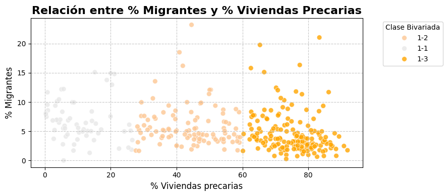

```python
plt.figure(figsize=(9, 4))
plt.title('Relación entre % Migrantes y % Viviendas Precarias', fontsize=16, fontweight='bold')

# Aseguramos que las columnas existan en gdf_bi
# Si no se hubieran añadido previamente, las añadiríamos aquí.
# Para este punto del notebook, ya deberían estar presentes de 9NZFIHhO3YHm
if 'porcentaje_migrantes_2024' not in gdf_biv.columns:
    gdf_biv['porcentaje_migrantes_2024'] = porcentaje_migrantes_2024
if 'porcentaje_viviendas_precarias_2024' not in gdf_biv.columns:
    gdf_biv['porcentaje_viviendas_precarias_2024'] = porcentaje_viviendas_precarias_2024

# Usar gdf_bi ya que contiene tanto los porcentajes como la clasificación bivariada
sns.scatterplot(
    data=gdf_biv,
    x='porcentaje_viviendas_precarias_2024',
    y= 'porcentaje_migrantes_2024',
    hue='bi_class',
    palette=BIVARIATE_COLORS,
    s=50, # Tamaño de los puntos
    alpha=0.8, # Transparencia
    ax=plt.gca() # Usar los ejes actuales
)

plt.xlabel('% Viviendas precarias', fontsize=12)
plt.ylabel('% Migrantes', fontsize=12)
plt.grid(True, linestyle='--', alpha=0.7)
plt.legend(title='Clase Bivariada', bbox_to_anchor=(1.05, 1), loc='upper left')
plt.tight_layout()
plt.show()
```

# Análisis y discusión

Antes que interpretar la relación entre las dos variables propuestas, corresponde analizar el comportamiento de cada una de estas por separado. Para ello además, se debe tener en cuenta el contexto general de la demografía de la zona de estudio. Así, hay que recalcar que las comunas analizadas han enfrentado un descenso de su población, pasando de 750.391 habitantes el 2017 a 715.588 personas en el 2024. La única comuna que vió un aumento de su población fue Concón, que pasó de 42.152 habitantes el 2017 a 43.048 habitantes el 2024 (INE, 2024). Ahora bien, en cuanto al fenómeno migratorio y en vista de los resultados obtenidos para la distribución de su porcentaje en la Provincia de Valparaíso, se observa que existe un aumento considerable de su proporción dentro del territorio. Si en 2017 en promedio por cada zona censal había un 1,8% de migrantes, al 2024 ese promedio era del 5,4%, es decir, que en el período de esos 7 años se triplicó el promedio de migrantes en cada zona censal de la Provincia de Valparaíso. Incluso, si en 2017 se registraban a lo sumo (en un par de zonas censales) peaks de entre 8 y 10% de migrantes, en 2024 se pueden verificar unas cuantas zonas censales con entre 15 y 20% migrantes.

Lo anterior se condice con la situación migratoria del país que ha enfrentado en los últimos años, y es más, supera al crecimiento del porcentaje de migrantes a nivel nacional: en Chile se observó una duplicación de este porcentaje entre el 2017 y el 2024 de un 4,4% al 8,8%, respectivamente (OCUC, 2025), en circunstancias que como se mencionó, en la Provincia de Valparaíso este porcentaje se triplicó. Si este análisis es llevado a nivel comunal, a partir de la comparativa entre los diagramas de caja, se puede observar cómo la mediana de la variable en todas las comunas al menos se duplicó, teniéndose a Concón y Casablanca como las comunas donde más aumentó el porcentaje de migrantes (5 veces y 9 veces más, respectivamente). Sobre esta última, se observa una preponderancia de que en zonas rurales se den porcentajes de migrantes relevantes comparativamente, probablemente de la mano de la dedicación a labores como jornaleros agrícolas.

Cabe señalar que al ver los mapas individuales, los cambios vistos se limitan a las áreas urbanas de las que se poseen datos del Censo 2024. A partir de esto, se comprueba que para el caso de las zonas urbanas, los sectores con mayor porcentaje de migrantes corresponden a zonas periféricas del Gran Valparaíso y otras alicaídas de la comuna de Valparaíso, vale decir, el sector del Almendral que experimenta un despoblamiento y deterioro de su calidad urbana (Aravena, 2024). Por otro lado, en el 2017 se presentan varias zonas censales rurales con porcentaje de migrantes un tanto mayores, sin embargo al 2024 esto es solo comparable con el entorno de Casablanca que, de todos modos, se muestra como uno se los sectores de mayor crecimiento de la variable estudiada.

Antes de continuar con el análisis bivariado, vale mencionar que el presente estudio ha contado con ciertos escollos; no en cuanto a la asimilación de las variables entre los Censos (de hecho, estas fueron perfectamente replicables), sino más bien en cuanto al alcance territorial de los datos, es decir, que la desagregación espacial del Censo 2017 incluía varias zonas censales más que la del Censo 2024, quedando para efectos del análisis las zonas rurales principalmente de esta últimamente excluidas. Ello hizo necesario agregar mapas base a las cartografías para una mejor orientación espacial del lector, puesto que de lo contrario, hubiese parecido tratarse de islas las comunas estudiadas.

Respecto a una comparación temporal de estos mapas bivariados, esta se limita a las zonas urbanas, dado que como ya se ha dicho, el archivo ‘.parquet’ que contiene la información del Censo 2024 se limita a esas áreas. Aún así, los principales cambios se aprecian en los sectores periféricos de Valparaíso y Viña del Mar junto a Laguna Verde, donde siguen en el tiempo una tendencia en que reducen su porcentaje de viviendas precarias (adquieren un tono un tanto más pálido) pero manteniendo los rangos de porcentaje de migrantes. Este patrón se repite para las áreas urbanas de Quintero y Puchuncaví, mientras que Concón se presenta invariable. Esta visualización permite focalizar de mejor manera las posibles políticas públicas que se lleguen a elaborar para amenguar estas problemáticas, así como servir de insumo para la planificación territorial del entorno que, más allá de considerar las diversas barreras que enfrenta este aspecto (DO, 2023), representan instancias donde se puedan corregir a futuro las tendencias sociodemográficas desfavorables que enfrenta la zona estudiada (Orellana, 2025).

Por último, vale la pena resaltar que todo lo realizado en este estudio, en cuanto al manejo de datos y su análisis, se configura como un procedimiento verdaderamente útil para diversos análisis territoriales. Ello dado que en rigor es aplicable a cualquier estudio multivariable a partir de parámetros disponibles en fuentes oficiales como Censos. Estos, aparte de tratarse de datos oficiales y confiables, son valiosos al estar asociados a una unidad territorial definida. Luego la desagregación de esta información en el territorio permite analizar y comparar los comportamientos de los datos medidos en el espacio. Con esto, luego se pueden llevar diversos estudios de interés con un detalle tal que se pueden usar como base para la implementación de políticas públicas o también de proyectos privados los que, al tener visto estos comportamientos en el territorio, pueden dimensionar el verdadero impacto y rentabilidad de sus emprendimientos, reduciendo incertezas y optimizando la asignación de recursos.

# Conclusiones

En base a los información recabada para el presente informe, se puede establecer que la Provincia de Valparaíso viene enfrentando desde el 2017 importantes cambios sociodemográficos. Por un lado se tiene que su población total ha decrecido en circunstancias que su cantidad de migrantes se ha triplicado y el número de viviendas ha crecido levemente y aún se presenta un déficit habitacional. Esto se explica por varios procesos tales como migración interna nacional (fundamentalmente hacia la capital que concentra más oportunidades económicas o hacia Quilpué y Villa Alemana que han crecido exponencialmente durante las últimas décadas a modo de comunas dormitorio), construcción de nuevos soluciones habitacionales (ya sean informales o segunda vivienda) que responden a ese aumento del número de viviendas, y por supuesto al fenómeno migratorio que justamente entre 2017 y 2024 tuvo su auge en Chile.

En cuanto al análisis más detallado a partir de la información trabajada a nivel de zonas censales, se puede concluir que no existe una clara correlación entre los porcentajes de migrantes de una zona dada considerando el porcentaje de viviendas precarias que allí exista. Esto es, que ante el triplicamiento (o más en comunas puntuales) del porcentaje de migrantes entre el 2017 y 2024, no se tuvo tal aumento para el porcentaje de viviendas precarias en esas mismas zonas.

Lo anterior no necesariamente nos debe conducir a la idea de que entonces los migrantes que han llegado a las comunas de la Provincia de Valparaíso están sorteando la precariedad habitacional. De hecho, y tal como queda de manifiesto al observar la cantidad de migrantes en la zona del Almendral de Valparaíso, estas personas han acudido igualmente a zonas que enfrentan un deterioro urbano considerable que, si bien no se tratan de viviendas precarias bajo la definición de esta variable para el presente estudio (aquellas que cuentan con materiales precarios en sus techumbres), sí que tratan de inmuebles antiguos deteriorados y mal mantenidos fruto de la decadencia que enfrenta la zona. Es por esto, que se estima relevante el estudio futuro de esta situación en el que los migrantes vienen a concentrarse en zonas alicaídas en cuanto a su calidad urbana, revistiendo para ello de suma importancia del conocimiento del territorio a analizar (caracterización, noción histórica y situación actual) por parte de sus investigadores.

Se concluye que este tipo de análisis donde se desagrega espacialmente la información de interés facilita la correcta focalización en el territorio de la implementación de las políticas públicas que pudiesen elaborarse en distintas materias (en este caso habitacional y social). Finalmente, con relación al trabajo elaborado en sí, se concluye que análisis como éste son relevantes para determina ciertos fenómenos demográficos, siendo fundamentales para estos análisis el uso de Software y/o programas como pgAdmin, Jupyter, entre otros. Ante esto se recalca la utilidad que esta metodología tiene para el estudio del territorio, pudiendo servir para las más diversas comprobaciones del comportamiento en el tiempo de fenómenos tales como de migración, precarización de la vivienda, acceso a la salud, composición del hogar, educacional, inmobiliario, calidad y estado de infraestructura, entre otros.

# Bibliografía

- Aravena, I. (2024). Soñando Valparaíso: Lecciones de ciudades industriales y portuarias. Fundación P!ensa, Chile.
- DAP. (2026). Catastro Nacional de Campamentos 2026. Ministerio de Vivienda y Urbanismo, Chile.
- DO. (2023). CVE 2393907: Municipalidad de Valparaíso desiste del procedimiento de Evaluación Ambiental Estratégica del Plan Regulador Comunal de Valparaíso. Diario Oficial de la República de Chile, Chile.
- Duarte, M. (2022). Valparaíso: Radiografía urbana de la ciudad de Valparaíso. Fundación P!ensa, Chile.
- Fuentes, L. & Pezoa, M. (2017). Crecimiento urbano reciente del Gran Valparaíso. Revista 180: Arquitectura, Arte y Diseño, Chile.
- Herrera, R., et al. (2024). El desarrollo humano en las comunas de Chile. Programa de las Naciones Unidas para el Desarrollo, Chile.
- INE. (2017). Censo de Población y Vivienda 2024. Instituto Nacional de Estadísticas, Chile.
- INE. (2024). Censo de Población y Vivienda 2024. Instituto Nacional de Estadísticas, Chile.
- Maiz, P. (2023). Construyendo Valparaíso: Propuestas para enfrentar el déficit habitacional. Hanns Seidel Stiftung, Alemania.
- OCUC. (2025). Resultados preliminares sobre inmigración - Censo 2024. Centro Urbano de Investigación Territorial Observatorio de Ciudades de la Pontificia Universidad Católica de Chile, Chile
- Orellana, A., et al. (2025). Índice de Calidad de Vida Urbana 2024. Instituto de Estudios Urbanos y Territoriales de la Pontificia Universidad Católica de Chile, Chile.
- Panez, A. (2015). Desarrollo Metropolitano del Gran Valparaíso en debate: divergencias entre discursos y prácticas espaciales de sus actores políticos. Pontificia Universidad Católica de Valparaíso, Chile.

La importancia de desagregar espacialmente los datos que se manejan permite ver y analizar en más detalle los comportamientos de las variables en el territorio. Así, es posible ver comportamientos que se encontraban "ocultos" si se veían con una escala más pequeña.

# ANEXO

```
Cortes Jenks — % Migrantes:
[np.float64(3.48), np.float64(5.61), np.float64(nan)]
Cortes Jenks — % Viviendas precarias >= 16:
[np.float64(26.55), np.float64(59.24), np.float64(91.88)]

Distribucion de clases bivariadas:
bi_class
1-1     43
1-2     59
1-3    122
2-1     19
2-2     46
2-3     47
Name: count, dtype: int64

Todas las zonas tienen color asignado
```

[figure not shown]

```python
# Bivariado 2024 pero con mejora en la distribución estadística comparativa para la variable de % Migrantes:

censo24v_zonal['porcentaje_migrantes_2024'] = porcentaje_migrantes_2024
censo24v_zonal['porcentaje_viviendas_precarias_2024'] = porcentaje_viviendas_precarias_2024

# Cambiado a Quantiles para asegurar tres clases distintas y equilibradas
cls_x = mapclassify.Quantiles(censo24v_zonal['porcentaje_migrantes_2024'].values,    k=3)
cls_y = mapclassify.FisherJenks(censo24v_zonal['porcentaje_viviendas_precarias_2024'].values, k=3)

gdf_bi = censo24v_zonal.copy()
gdf_bi['class_x']  = cls_x.yb + 1
gdf_bi['class_y']  = cls_y.yb + 1
gdf_bi['bi_class'] = gdf_bi['class_x'].astype(str) + '-' + gdf_bi['class_y'].astype(str)
gdf_bi['color']    = gdf_bi['bi_class'].map(BIVARIATE_COLORS)

print('Cortes Jenks — % Migrantes:')
print([round(b, 2) for b in cls_x.bins])
print('Cortes Jenks — % Viviendas precarias >= 16:')
print([round(b, 2) for b in cls_y.bins])
print(f'\nDistribucion de clases bivariadas:')
print(gdf_bi['bi_class'].value_counts().sort_index())

sin_color = gdf_bi[gdf_bi['color'].isna()]
if len(sin_color) == 0:
    print('\nTodas las zonas tienen color asignado')
else:
    print(f'\nAtencion: {len(sin_color)} zonas sin color: {sin_color["bi_class"].unique()}')


def crear_leyenda_bivariada(ax, colores, xlab, ylab, dim=3):
    for i in range(1, dim + 1):
        for j in range(1, dim + 1):
            ax.add_patch(plt.Rectangle(
                ((i - 1) / dim, (j - 1) / dim),
                1 / dim, 1 / dim,
                transform=ax.transAxes,
                facecolor=colores[f'{i}-{j}'],
                edgecolor='white',
                linewidth=2.5,
                clip_on=False
            ))
    ax.set_xlim(0, 1)
    ax.set_ylim(0, 1)
    ax.set_xticks([])
    ax.set_yticks([])
    ax.text(0.5, -0.22, xlab,
            ha='center', va='top', fontsize=7.5, transform=ax.transAxes,
            color='#222', fontweight='bold', clip_on=False)
    ax.text(-0.22, 0.5, ylab,
            ha='center', va='center', fontsize=7.5, transform=ax.transAxes,
            rotation=90, color='#222', fontweight='bold', clip_on=False)



import matplotlib.patheffects as pe
from matplotlib.lines import Line2D
import geopandas as gpd # Asegurarse de importar geopandas

# ── Figura y layout ───────────────────────────────────────────────────────────
fig = plt.figure(figsize=(16, 12))
fig.patch.set_facecolor('#f5f0e8')      # fondo

ax_map = fig.add_axes([0.02, 0.05, 0.70, 0.82])   # mapa: izquierda 70%
ax_leg = fig.add_axes([0.75, 0.20, 0.20, 0.20])   # leyenda: esquina derecha

# ── Mapa ─────────────────────────────────────────────────────────────────────
ax_map.set_facecolor('#b8d4e8')         # azul suave

# Asegurar que censo24v_zonal sea un GeoDataFrame y tenga las columnas necesarias.
# Esto es similar a lo que hace la celda PQSk-vgL2-iF.
if not isinstance(censo24v_zonal, gpd.GeoDataFrame):
    censo24v_zonal = gpd.GeoDataFrame(censo24v_zonal, geometry=gpd.GeoSeries.from_wkb(censo24v_zonal['SHAPE']), crs='epsg:4326')
    # Añadir columnas de porcentaje si no están presentes (se necesitan para gdf_bi)
    if 'porcentaje_migrantes_2024' not in censo24v_zonal.columns:
        censo24v_zonal['porcentaje_migrantes_2024'] = porcentaje_migrantes_2024
    if 'porcentaje_viviendas_precarias_2024' not in censo24v_zonal.columns:
        censo24v_zonal['porcentaje_viviendas_precarias_2024'] = porcentaje_viviendas_precarias_2024

# Definir gdf_comunas y gdf_centroides a partir de censo24v_zonal
gdf_comunas = censo24v_zonal.dissolve(by='COMUNA')
gdf_centroides = gdf_comunas.copy()
gdf_centroides.geometry = gdf_comunas.geometry.centroid.to_crs(epsg=4326)

# Asegurar que gdf_bi sea un GeoDataFrame antes de usar sus atributos geométricos
# Esta parte ya estaba en la corrección anterior.
if not isinstance(gdf_bi, gpd.GeoDataFrame):
    gdf_bi = gpd.GeoDataFrame(gdf_bi, geometry=gpd.GeoSeries.from_wkb(gdf_bi['SHAPE']), crs='epsg:4326')

# Zonas censales (relleno)
gdf_bi.plot(
    color=gdf_bi['color'].tolist(), ax=ax_map,
    zorder=2
)
# Zonas censales (bordes)
gdf_bi.boundary.plot(
    ax=ax_map,
    color='#aaaaaa', # Usar 'color' para LineString
    linewidth=0.2,
    zorder=2
)

# Limites comunales: linea gruesa y oscura
gdf_comunas.plot(
    ax=ax_map, facecolor='none', edgecolor='#111111',
    linewidth=2.8, zorder=4
)

# Etiquetas con stroke blanco
for _, row in gdf_centroides.iterrows():
    txt = ax_map.annotate(
        row.name, # Corregido: Usar row.name para obtener el nombre de la comuna del índice
        xy=(row.geometry.x, row.geometry.y),
        ha='center', va='center',
        fontsize=10.5, fontweight='bold', color='#111111', zorder=6
    )
    txt.set_path_effects([pe.withStroke(linewidth=5, foreground='white')])

# Marco del mapa: borde fino gris
for spine in ax_map.spines.values():
    spine.set_visible(True)
    spine.set_color('#bbbbbb')
    spine.set_linewidth(0.8)
ax_map.set_xticks([])
ax_map.set_yticks([])

# ── Bloque de titulos (espacio figura) ──
fig.text(0.37, 0.965, 'MAPA BIVARIADO', ha='center',
         fontsize=20, fontweight='bold', color='#1a1a2e')
fig.text(0.37, 0.938, '% Migrantes  x  % Viviendas precarias', ha='center',
         fontsize=12, color='#444', style='italic')
fig.text(0.37, 0.914, 'Provincia de Valparaíso  .  Zonas Censales  .  Censo 2017',
         ha='center', fontsize=9.5, color='#777')

# Linea separadora bajo el titulo
fig.add_artist(Line2D([0.02, 0.72], [0.902, 0.902],
                      transform=fig.transFigure,
                      color='#1a1a2e', linewidth=1.5))

# Fuente (pie de figura)
fig.text(0.02, 0.017, 'Fuente: Censo 2024, INE Chile',
         ha='left', fontsize=8, color='#999', style='italic')

# ── Leyenda bivariada ───
# Estilo del axes de leyenda: fondo blanco con borde gris
ax_leg.set_facecolor('white')
for spine in ax_leg.spines.values():
    spine.set_visible(True)
    spine.set_color('#cccccc')
    spine.set_linewidth(1.2)

crear_leyenda_bivariada(
    ax_leg, BIVARIATE_COLORS,
    xlab='% Migrantes  →',
    ylab='% Viviendas precarias  →'
)
ax_leg.set_title('Leyenda', fontsize=8.5, fontweight='bold', pad=7, color='#333')

plt.show()
```